# Introduction time and spread of a resistance variant

This Vignette details the GeneCastR pipeline on sixteen Ugandan districts surveyed annually from 2016 to 2022 for the PfKelch13 C469Y artemisinin-resistance marker.

```r
library(GeneCastR)
```

## The model

We model in discrete time with `M` steps per unit of time, in our running example one unit of time is equal to one year, with \(M=16\) steps per year. We denote the allele count at time \(t\) with \(k_t\) and set \(k_0=0\), meaning that the focal allele is yet to be imported at initialisation.

We denote the first arrival time with `t*`. The arrival event occurs with constant hazard `theta` per unit time, so that \(t^* \sim Geometric(1-\exp\{-\theta/M\})\). At `t*` the deme receives a founding count drawn from `Poisson(lambda)` conditioned on being non-zero, where \(\lambda \geq 0\).

From `t*` onward \(k_t\) follows the following Wright-Fisher dynamics

$$k_{t+1} \mid k_t \sim \mathrm{Binomial}\!\left(N_{\mathrm{lat}},\; \frac{f_t(1+\alpha)}{1+\alpha f_t}\right), \qquad f_t = k_t/N_{\mathrm{lat}},$$

if \(k_t\geq 1\), and \(k_{t+1}\sim Poi(\lambda)\) if \(k_t=0\). This means that a lineage can die out and the deme be re-founded, any number of times.

Observation surveys are modelled as binomial samples. Given a latent frequency \(f_t=k_t/N_{\mathrm{lat}}\) at time \(t\), a survey of \(n\) gene copies is assumed to follow \(x_t \sim Binomial(n, f_t)\).

### Parameterisation

The parameters are all cast as **per unit time** to allow for different choices of time resolution \(M\). Each is transformed so that it has a ‘per year’ interpretation invariant to `M`, summarised in the table below; the rest of this section says why each transform has the form it does.

| parameter | meaning | support | state-space quantity | transform |
| --- | --- | --- | --- | --- |
| `A` | growth advantage per unit time | `A > -1` | `alpha`, selection per *step* | `alpha = (1 + A)^(1/M) - 1` |
| `nu` | gene flow, in frequency units per unit time | `nu > 0` | `lambda`, Poisson mean per *step* | `lambda = nu * N_eff` |
| `N_eff` | effective size, in gene copies | `N_eff > 0` | `N_lat`, lattice size in copies | `N_lat = max(2, round(M * N_eff))` |
| `theta` | hazard of founding, per unit time | `theta > 0` | `p`, founding chance per *step* | `p = 1 - exp(-theta / M)` |

A growth advantage of `A` over a unit of time is `M` steps of `alpha`, so `(1 + alpha)^M = 1 + A`. Sampling is done on `u = log(1 + A)`, which makes `alpha = exp(u/M) - 1`.

`N_lat` is linear in both `M` and `N_eff` Binomial sampling gives the frequency a variance of `f(1-f)/N_lat` in one step. Over the `M` steps in a year that accumulates to `M * f(1-f) / N_lat`, and setting it equal to `f(1-f)/N_eff` – the drift of a single Wright-Fisher generation in a population of `N_eff` – forces `N_lat = M * N_eff`.

```r
drift_per_year <- function(M, N_eff = 15.6, f = 0.3, N_lat = NULL) {
  nl <- if (is.null(N_lat)) gc_nlat(log(N_eff), M) else N_lat
  P <- gc_kernel(nl, 0)                       # neutral
  k <- round(f * nl); g <- (0:nl) / nl
  mean_f <- sum(P[k + 1L, ] * g)
  M * sum(P[k + 1L, ] * (g - mean_f)^2)       # variance per step, times M
}
c(M8 = drift_per_year(8), M16 = drift_per_year(16),
  M32 = drift_per_year(32), M128 = drift_per_year(128),
  target = 0.3 * 0.7 / 15.6)
```

```
#>         M8        M16        M32       M128     target
#> 0.01354138 0.01344000 0.01348233 0.01345891 0.01346154
```

Hold `N_lat` fixed instead and a year’s worth of drift doubles every time the step halves:

```r
vapply(c(8, 16, 32, 64), drift_per_year, numeric(1), N_lat = 250L)
```

```
#> [1] 0.00672 0.01344 0.02688 0.05376
```

Two parameters are moved on a log scale, because both are positive and neither is bounded above: `u = log(1 + A)` and `z = log N_eff`. These are the names the sampler’s internals and its diagnostics use – `accept_z` and `step_z` in `fit$info` are the `z` block’s – while the draws come back on the scale with a meaning, as `A` and `N_eff[d]`.

`A` and `N_eff` are shared across the demes by default, which is the fit presented below. `gc_control()` will give either one a per-deme version: `neff = "hierarchical"` draws each `z_d` from `N(mu, sigma^2)`, so `mu` and `sigma` are the mean and spread of the log effective size across demes, and `selection = "hierarchical"` draws each `u_d` from `N(mu_u, sigma_u^2)`, `mu_u` and `sigma_u` being the same two for the log growth advantage. Both spreads carry priors whose mode is at zero, so a per-deme version can collapse back onto the shared one rather than being held apart by the prior. `theta`, for its part, is given an `Exponential(rate)` prior with `rate` defaulting to the length of the observation window.

The panel-level size is named for the structure that was fitted. Under the shared default there is one size and nothing to average over, so it comes back as `N_eff`, with its log as `log_N_eff`. Under `neff = "hierarchical"` the same slot instead holds the exponential of the mean *log* size, which describes a typical deme rather than any particular one, and is reported as `exp_mu` with `mu` beneath it. `sigma` is not a parameter under the shared default and is reported as `NA`.

`N_lat` is an integer, because it counts gene copies, so the likelihood is piecewise constant in `N_eff`: two values that round to the same lattice give exactly the same model. Rounding is half-to-even, and the floor of 2 is there because a lattice of 0 or 1 has no interior for drift or selection to act on.

The invariance is close but not exact: the full likelihood still shifts by about 0.6 nats between `M = 16` and `M = 32`, and 1.8 nats across the whole range from `M = 8` to `M = 64`. `M = 16` is the resolution the stored fit uses.

### The shared-parameter model in full

Collecting the above, with the defaults of `gc_control()`, for a panel of \(D\) demes observed over \(T\) steps at \(M\) steps per unit of time. One growth advantage, one effective size, one flow rate and one hazard serve the whole panel; each deme keeps its own arrival time and its own path.

Priors, written on the scale the sampler moves:

$$u = \log(1+A) \sim N(0, \tau^2), \qquad \tau = 1,$$ $$z = \log N_{\mathrm{eff}} \sim N(\mu_0, s_0^2), \qquad \mu_0 = \log 15,\; s_0 = 1.5,$$ $$\nu \sim \mathrm{HalfNormal}(0.02), \qquad \theta \sim \mathrm{Exponential}(\mathrm{span}).$$

Transforms onto the lattice:

$$\alpha = e^{u/M} - 1, \qquad N_{\mathrm{lat}} = \max\{2, \mathrm{round}(M e^{z})\}, \qquad \lambda = \nu e^{z}, \qquad p = 1 - e^{-\theta/M}.$$

Then for each deme \(d = 1, \dots, D\) independently, an arrival time, a founding count and a path:

$$t^*_d \sim \mathrm{Geometric}(p) \;\text{ on } \{1, 2, \dots\}, \qquad k_{d,0} = \dots = k_{d,\,t^*_d - 1} = 0,$$ $$k_{d,\,t^*_d} \sim \mathrm{Poisson}(\lambda) \mid {\geq 1}, \qquad k_{d,\,t^*_d:T} \sim \mathrm{WF}(\alpha, N_{\mathrm{lat}}, \lambda),$$

where \(\mathrm{WF}\) is one draw of the path given above: a \(\mathrm{Binomial}(N_{\mathrm{lat}}, \psi(f_t, \alpha))\) step while the deme holds a copy and a \(\mathrm{Poisson}(\lambda)\) re-entry while it is empty. The selection tilt is \(\psi(f, \alpha) = f(1+\alpha) / (1 + \alpha f)\), the frequency written in the Binomial above: it carries \(f\) upwards whenever \(\alpha > 0\) and fixes \(\psi(0,\alpha) = 0\), \(\psi(1,\alpha) = 1\), so neither absence nor fixation is disturbed by selection. Finally each survey \(j\) in deme \(d\), taken at step \(s_{dj}\) and typing \(n_{dj}\) gene copies,

$$x_{dj} \sim \mathrm{Binomial}\!\left(n_{dj},\; k_{d,\,s_{dj}}/N_{\mathrm{lat}}\right).$$

Four details of that generative story are worth stating, because they are places the implementation could have cut a corner and does not.

The arrival time is **not** a sampled quantity. It is summed out exactly in the same backward pass that evaluates the likelihood, so its posterior is a normalisation of a row already computed and carries no Monte-Carlo error.

\(\mathrm{Geometric}(p)\) is unbounded, so \(P(t^* > T) = e^{-\theta \cdot \mathrm{span}}\) is positive: a deme may simply not have been reached yet, and a deme never seen positive is not forced to have been reached and then hidden.

The founding draw is conditioned on being non-zero, while the re-entry draw is not – an empty deme stays empty with probability \(e^{-\lambda}\). Both are truncated at \(N_{\mathrm{lat}}\) with the tail folded onto the last cell, so each row sums to one rather than leaking mass.

For the running example \(D = 16\), \(M = 16\), \(\mathrm{span} = 12\) years and so \(T = 192\) steps.

In the next sections we explain how to use the package to infer model parameters, including selection, effective population size, and importation time.

## Data

Input is one row per survey.

```r
d <- gc_example_data(M = 16)
```

```
#> 16 row(s) with n == 0 dropped (no information).
```

```r
d
```

```
#> <GCData>
#>   demes    : 16 (Agago, Amolatar, Arua, ...)
#>   surveys  : 96 (42 non-zero)
#>   window   : 2015 to 2022   M = 16, T = 112 steps
#>   never positive: 2 deme(s) -- Jinja, Kanungu
```

The window printed there is the default: `t0` sits one unit of time before the first survey. Where the window *opens* is a prior claim about the earliest possible arrival rather than anything the data say, so it is made at fit time instead – see `lead_in` below.

## Fitting

Parameter posteriors can be drawn using a Metropolis-within-Gibbs scheme in which the true likelihood is evaluated exactly. An example fit output looks like this.

```r
stored <- gc_example_fit()
fit <- stored$fit
fit
```

```
#> <GCFit>  Poisson flow, t* geometric (may postdate the record)
#>           (t* = the first non-zero draw)
#>   data    : 16 demes, 96 surveys, M = 16, T = 192
#>   window  : 2010 to 2022, lead-in 96 steps
#>   chains  : 4 x 4000 (2000 warm-up), 8000 draws retained
#>   time    : 3347.7 s on 4 cores
#>
#>           variable  median      q5     q95 rhat ess_bulk
#>                  u  0.1495 -0.1421  0.3705 1.01      877
#>                  A  0.1612 -0.1325  0.4484 1.01      877
#>                 nu  0.0255  0.0111  0.0472 1.00      903
#>              N_eff 15.6002  7.9211 30.0540 1.01      866
#>              theta  0.1804  0.1063  0.3233 1.00     1199
#>  p_beyond_baseline  0.1148  0.0207  0.2792 1.00     1199
```

To produce such a fit given data `d` with default priors we can run:

```r
fit <- GCFit$new(d, chains = 4, iter = 4000, warmup = 2000, seed = 101,
                 cores = 4, lead_in = 6 * 16, control = gc_control(selection = "shared"))
```

`lead_in` is the lead-in before the first survey, counted in steps, so `6 * 16` is six years at `M = 16` and puts `t0` in 2010. It is the earliest arrival the model will allow. A `t*` posterior piled up against `t0` is the sign that a lead-in is too short to hold the arrival it is being asked to date. `gc_control` allows users to modify priors and model hierarchical structure, see the appendix for a description of functionality; for default use, omit the argument.

Once complete, one can plot parameter mcmc traces:

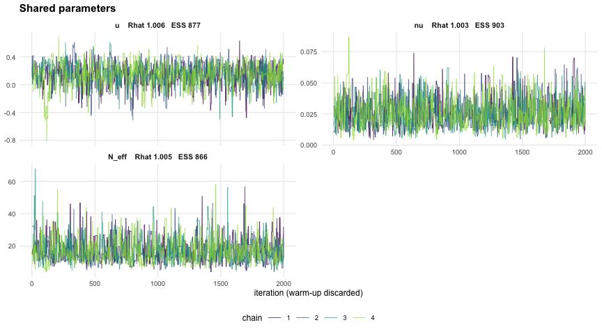

```r
gc_plot_trace(fit)
```

The same draws as histograms, with the chains kept apart. Disagreement between chains shows here as displaced humps, which a shared histogram hides.

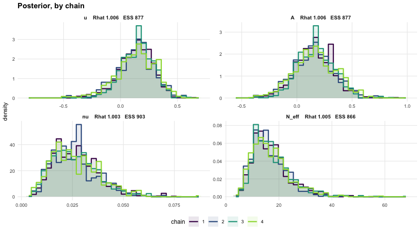

```r
gc_plot_hist(fit)
```

Pairwise, to tell a ridge – two parameters the data cannot separate – from one parameter merely absorbing signal from another:

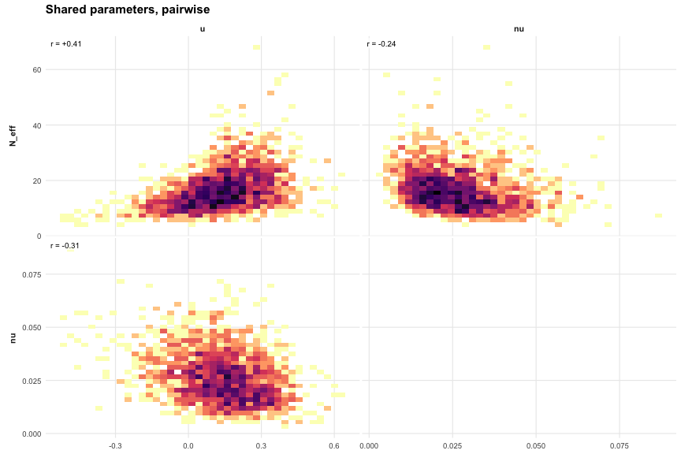

```r
gc_plot_pairs(fit)
```

`N_eff` is the one effective size the whole panel shares, this being the default. `gc_control(neff = "hierarchical")` gives each deme its own instead, drawn from `N(mu, sigma^2)`; `sigma` then becomes a parameter, the panel level is reported as `exp_mu`, and `gc_plot_trace(fit, "N_eff")` has sixteen traces to show rather than one.

### The growth advantage

`u` is what the sampler moves, but `A = exp(u) - 1` is the quantity with a meaning: the proportional change in frequency per year that selection buys.

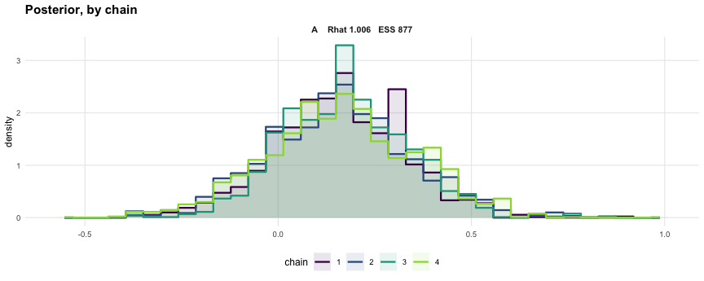

```r
gc_plot_hist(fit, "A", ncol = 1)
```

```r
A <- as.numeric(posterior::as_draws_matrix(fit$draws)[, "A"])
round(stats::quantile(A, c(.025, .05, .25, .5, .75, .95, .975)), 3)
```

```
#>   2.5%     5%    25%    50%    75%    95%  97.5%
#> -0.176 -0.132  0.042  0.161  0.278  0.448  0.510
```

```r
c(`P(A > 0)` = mean(A > 0), `P(A > 0.25)` = mean(A > 0.25))
```

```
#>    P(A > 0) P(A > 0.25)
#>    0.824375    0.293500
```

The posterior favours a positive advantage without excluding neutrality: about a sixth of its mass lies below zero. Two things to hold alongside that: every district here is one where C469Y was observed, and conditioning of that kind inflates apparent selection; and the flow term competes with selection to explain late-appearing demes, so `A` is not identified independently of `nu`.

Acceptance rates and the guard counts are in `fit$info`. The `N_eff` bounds are rejections applied *before* the likelihood is evaluated: they stop a wild proposal allocating a vast lattice, and the rejections they generate are the negative feedback that keeps step-size adaptation stable.

```r
fit$info[, c("chain", "accept_z", "accept_u", "accept_nu", "guard_rejects")]
```

```
#>   chain accept_z accept_u accept_nu guard_rejects
#> 1     1   0.2460   0.3175    0.2960           488
#> 2     2   0.2960   0.2785    0.2455           344
#> 3     3   0.3050   0.2820    0.3745           289
#> 4     4   0.2905   0.3075    0.3360           424
```

## Projections

```r
pr <- stored$pr
pr
```

```
#> <GCProjection>
#>   3840 rows: 16 demes x 240 steps (192 smoothed, 48 projected)
#>   window   : 2010.062 to 2025
#>   draws    : 200, 400 paths each
#>   exceedance thresholds: 0.01, 0.05, 0.1
#>   P(t* beyond the record): mean 0.074, max 0.627
#>
#>   at 2025: mean P(present) 0.807, mean median f 0.090
```

```r
pr <- fit$project(horizon = 3, n_draws = 200, n_paths = 400,
                  thresholds = c(0.01, 0.05, 0.10))
```

`pr$curves` is one row per deme and step.

```r
names(pr$curves)
```

```
#>  [1] "deme"            "step"            "time"            "phase"
#>  [5] "f_mean"          "f_q2.5"          "f_q25"           "f_q50"
#>  [9] "f_q75"           "f_q97.5"         "p_present"       "p_present_q2.5"
#> [13] "p_present_q50"   "p_present_q97.5" "p_exceed_1"      "p_exceed_5"
#> [17] "p_exceed_10"     "pmf_tfirst"      "cdf_tfirst"      "pmf_test"
#> [21] "cdf_test"
```

Inside the window these are *smoothed*: every survey in the deme, later ones included, informs the state at each step. Beyond the last survey the same kernel propagates the smoothed lattice distribution forward.

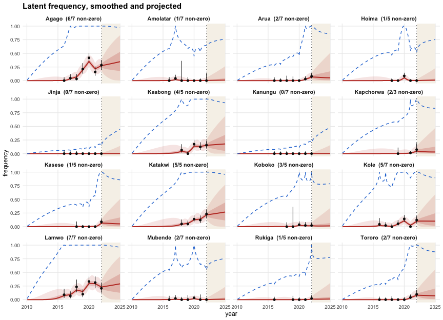

```r
gc_plot_frequency(pr)
```

Two distinctions in that table are easy to lose and both matter.

**`f_q*` are predictive; `p_present_q*` are not.** The frequency quantiles integrate the parameters, the latent path and the Wright-Fisher noise, so `f_q97.5` is a bound on the frequency itself. The presence quantiles hold the parameters out: they say how well the data pin a probability, not how uncertain the outcome is. Presence is a Bernoulli whose probability is itself uncertain, and the across-draw spread is only part of that variance.

**The `f_*` columns are unconditional.** The atom at zero carries `1 - p_present`, so a quantile below that level is exactly zero, and a band resting on zero means absence is the likelier state rather than a frequency near zero.

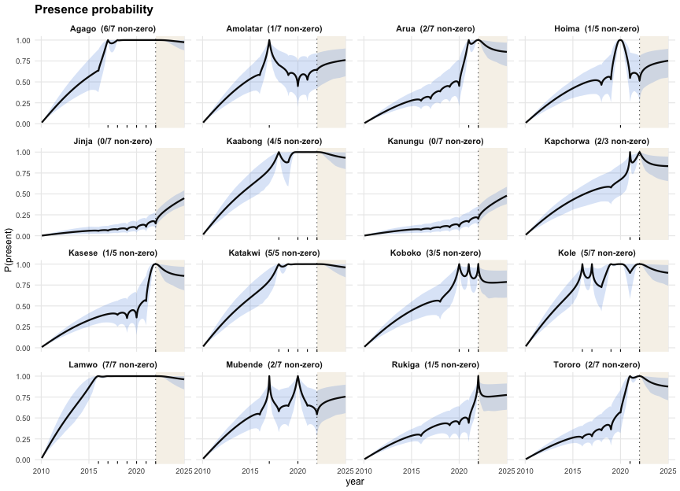

```r
gc_plot_present(pr)
```

`P(present)` is not monotone. It dips between surveys and recovers at each non-zero one, because a deme can go extinct and be re-seeded. Under a single introduction it could only ever rise.

Exceedance is computed on the lattice for every draw rather than from a binned density: the threshold falls between lattice points and the binning error does not average out.

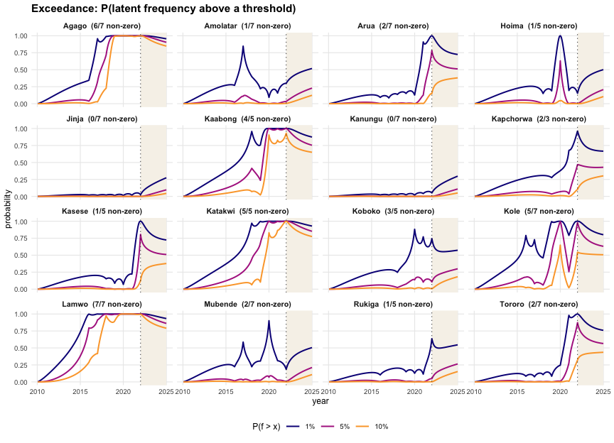

```r
gc_plot_exceed(pr)
```

## Introduction times

Three times, and they are not interchangeable.

`t*` is a parameter, obtained **analytically**: the backward table is already built for the likelihood, so its posterior is a normalisation of a row that has already been computed, with no Monte-Carlo error at all.

`T_first` is the first step the variant is present. In this model the founding event deposits a copy at `t*` and nothing is present before it, so `T_first` is identically `t*`. Computing it from sampled paths anyway is a check that the two routes agree.

`T_est` is the start of the excursion that produced the first count anyone actually saw: walk back from the first survey with a non-zero reading until the deme is empty. It is a path functional – no marginal of the smoother says when that excursion began – so it needs sampled paths, and it is the only expensive output here. It is undefined in a deme that was never detected, there being no observed lineage to date, and it does not condition on survival: the lineage that was seen need not be the one still present at the end.

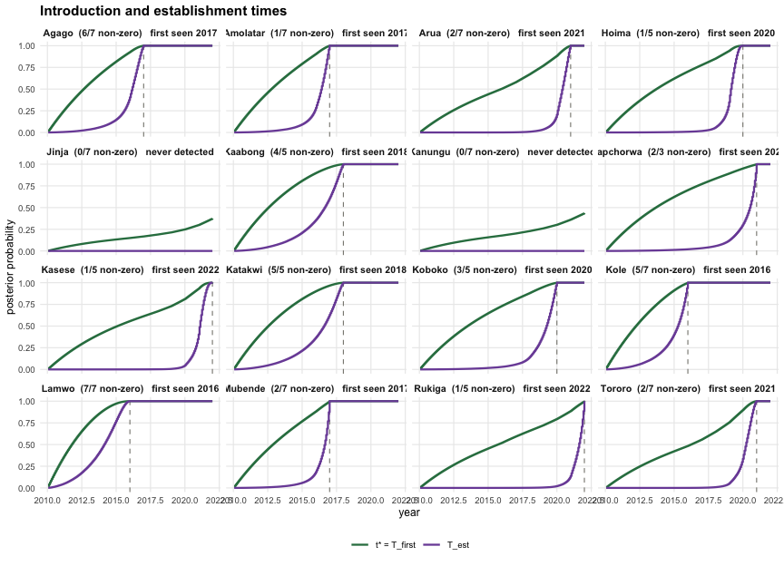

```r
gc_plot_times(pr, "cdf")
```

Both curves reach one, and both stop at the dashed line – the first detection. That line is a hard bound: the excursion carrying the detected copy must have begun before the copy was seen.

The gap between the curves is the span over which earlier arrivals came and went before the one that was eventually caught. Where the two nearly coincide, as in Lamwo, the variant was detected soon after it arrived and there was no room for turnover. Where purple stays flat for years while green climbs, as in Arua or Rukiga, the variant very probably arrived long before the lineage that was actually seen, and whatever came first died out.

The two never-detected demes have no purple curve at all.

The same two quantities as densities, which show where the mass actually is rather than where it has accumulated. Densities are per unit time, so both are on one scale whatever `M` is, and each integrates to one in a deme that was detected.

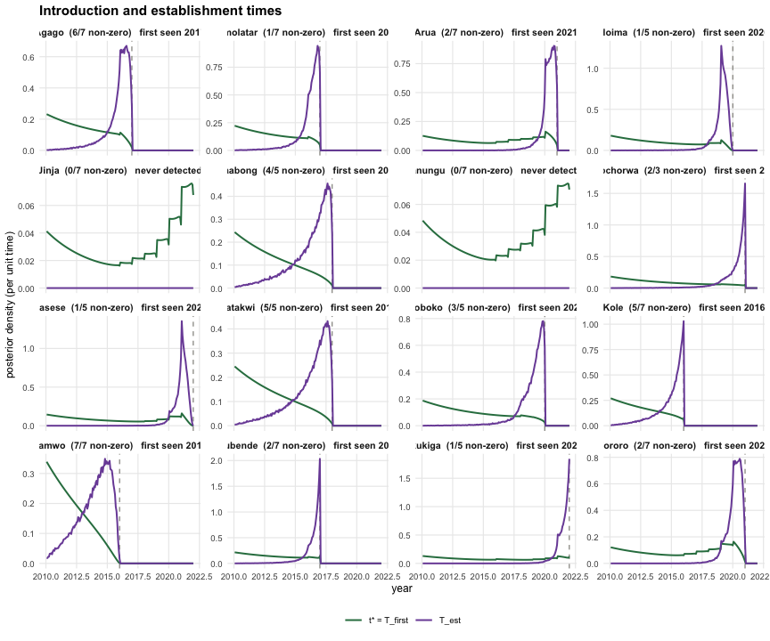

```r
gc_plot_times(pr, "pmf")
```

Multiple modes in a `T_est` density are successive extinction and recolonisation cycles, each one a plausible era for the founding of the lineage that was detected.

Every sampled path carries both times, so their joint distribution comes for free and is kept in `pr$joint`. Its diagonal is the probability that the lineage which was detected is the one that originally arrived – a quantity neither marginal can give, since both are compatible with either history. `gc_plot_joint()` draws it.

```r
J <- pr$joint
share <- vapply(seq_along(pr$demes$deme),
                function(k) sum(diag(J[, , k])), numeric(1)) /
         pmax(pr$demes$p_alive_T, 1e-12)
round(sort(stats::setNames(share, pr$demes$deme), decreasing = TRUE), 2)
```

```
#>     Lamwo   Mubende  Amolatar     Hoima      Kole    Tororo     Agago   Katakwi
#>      0.14      0.14      0.12      0.11      0.10      0.09      0.08      0.08
#>   Kaabong      Arua    Kasese    Rukiga    Koboko Kapchorwa     Jinja   Kanungu
#>      0.08      0.08      0.07      0.06      0.05      0.04      0.00      0.00
```

So in most demes the variant that was detected is **not** descended from the first arrival: the original lineage died out and a later one founded what was eventually seen.

## Cost

The fit is the expensive part; everything after it is seconds.

| one likelihood evaluation, 16 demes, `M = 16`, `T = 192` | 10 ms |
| --- | --- |
| 4 x 4000 sweeps, 4 cores | 3348 s |
| projection, 200 draws | ~9 s |
| path sampling, 400 paths per deme per draw | ~45 s |

The fit time is read back off the stored object rather than written down, so the table cannot drift away from the fit the rest of this vignette shows. It is one run on one laptop, and it moves with the machine and with whatever else that machine was doing at the time; the per-evaluation cost above is the figure to scale from.

`n_paths = 0` skips the path sampler, which is the fast path: `t*` is analytic and costs nothing, and `T_est` is the only expensive output.

The `N_eff` guard rejects about a tenth of the `z` proposals, and most of that is at the **lower** bound – 0.086 against 0.015 at the upper one. The adapted step is 1.45 against a posterior spread of 0.40 in `log N_eff`, so a step that is efficient for sampling routinely overshoots below `N_eff = 2`. Rejecting those before the likelihood is evaluated is what stops a wild proposal allocating a vast lattice, and it costs nothing, because the rejection happens before any work.

## Appendix: `gc_control()`

`gc_control()` carries everything about the model that is not the data: the priors, which parameters are shared across demes and which are not, what `t*` means, and the sampler’s own step sizes. It returns a plain list, named exactly as its arguments are, so a setting can be read back under the name it was passed and one object can serve several fits.

```r
ctl <- gc_control(selection = "hierarchical", mu_mean = log(30), tau = 0.5)
ctl$mu_mean
```

```
#> [1] 3.401197
```

```r
fit <- GCFit$new(d, chains = 4, iter = 4000, cores = 4, lead_in = 6 * 16,
                 control = ctl)
```

Anything left unnamed keeps its default, so `gc_control()` on its own is the model this vignette presents. The structural arguments come first because they decide which of the prior arguments mean anything at all.

| argument | what it sets | active in |
| --- | --- | --- |
| `neff` | one effective size for the panel (`"shared"`) or one per deme shrunk toward `mu` (`"hierarchical"`) | always |
| `selection` | one growth advantage for the panel (`"shared"`) or one per deme shrunk toward `mu_u` (`"hierarchical"`) | always |
| `tstar` | `"geometric"`, so `t*` may postdate the record, or `"uniform"` over the window | always |
| `founding` | what `t*` is: the first non-zero draw (`"conditional"`), a single copy (`"one"`), or the onset of the arrival rate (`"rate"`) | always |
| `tau` | `N(0, tau^2)` on `u = log(1 + A)` | always, but on different things: the shared `u`, or `mu_u` under `"hierarchical"` |
| `u_bounds` | rejection bounds on `u` | always |
| `nu_scale` | `HalfNormal(nu_scale)` on the flow rate `nu` | always |
| `lognu_bounds` | rejection bounds on `log nu` | always |
| `mu_mean`, `mu_sd` | `N(mu_mean, mu_sd^2)` | on the single `z = log N_eff` when `neff = "shared"`, on `mu` when `"hierarchical"` |
| `neff_bounds` | rejection bounds on `N_eff`, applied before the likelihood | always |
| `sigma2_shape`, `sigma2_rate` | `InvGamma` on `sigma^2`, the between-deme variance of `z` | **only** `neff = "hierarchical"` |
| `u_sigma_scale`, `u_sigma_df` | half-`t` on `sigma_u`, the between-deme spread of `u` | **only** `selection = "hierarchical"` |
| `tstar_rate` | rate of the `Exponential` prior on `theta`; `NULL` uses the window span | **only** `tstar = "geometric"` |
| `lntheta_bounds` | rejection bounds on `log theta` | **only** `tstar = "geometric"` |
| `target` | acceptance rate the warm-up adaptation aims at | always |
| `step_z`, `step_u`, `step_nu` | starting random-walk scales | always |

Three things that table is trying to make plain.

**Four prior arguments are inert unless you ask for the structure they belong to.** Setting `sigma2_shape` under the default `neff = "shared"` changes nothing, because there is no between-deme variance to put a prior on; the same goes for `u_sigma_scale` away from `selection = "hierarchical"`, and for `tstar_rate` under `tstar = "uniform"`. Nothing warns you, so it is worth checking `fit$control` against what you meant.

**The bounds are rejections, not densities.** A proposal outside them is refused before the likelihood is evaluated, which is what stops a wild draw from allocating a vast lattice, and the refusals are also the negative feedback that keeps step-size adaptation stable. They are not part of the model in the way the priors are, and a posterior pressed against one is a sign the bound is wrong rather than that the data have spoken.

**A parameter the chosen structure does not have is either absent from `fit$draws` or present and `NA`**, and which of the two depends on the parameter. `sigma` and `log_sigma2` are always there, and are `NA` unless `neff = "hierarchical"`. Everything else comes and goes:

| in `fit$draws` only when | variables |
| --- | --- |
| `neff = "shared"` | `N_eff`, `log_N_eff` (otherwise `exp_mu`, `mu`) |
| `tstar = "geometric"` | `theta`, `p_beyond_baseline` |
| `selection = "hierarchical"` | `u[d]`, `A[d]`, `mu_u`, `sigma_u` |

`fit$summary()` and the plotting functions consult `fit$control` and show only what the fit actually has, which is why the default reports six variables and never an empty `sigma` panel. `posterior::variables(fit$draws)` is the way to see the full set.

Defaults, with their justifications, are on the help page: `?gc_control`.